# R Notebook

```r
library(tidyverse)
library(janitor)
library(infer)
```

```r
clean_names <- read_csv("ames.csv")
```

[output not shown]

```r
view(clean_names)
```

```r
glimpse(clean_names)
```

```
Rows: 2,930
Columns: 82
$ Order           <dbl> 1, 2, 3, 4, 5, 6, 7, 8, 9, 10, 11, 12, 13, 14, 15, 16, 17, 18, 19, 20, 21, 22…
$ PID             <dbl> 526301100, 526350040, 526351010, 526353030, 527105010, 527105030, 527127150, …
$ MS.SubClass     <dbl> 20, 20, 20, 20, 60, 60, 120, 120, 120, 60, 60, 20, 60, 20, 120, 60, 50, 20, 2…
$ MS.Zoning       <chr> "RL", "RH", "RL", "RL", "RL", "RL", "RL", "RL", "RL", "RL", "RL", "RL", "RL",…
$ Lot.Frontage    <dbl> 141, 80, 81, 93, 74, 78, 41, 43, 39, 60, 75, NA, 63, 85, NA, 47, 152, 88, 140…
$ Lot.Area        <dbl> 31770, 11622, 14267, 11160, 13830, 9978, 4920, 5005, 5389, 7500, 10000, 7980,…
$ Street          <chr> "Pave", "Pave", "Pave", "Pave", "Pave", "Pave", "Pave", "Pave", "Pave", "Pave…
$ Alley           <chr> NA, NA, NA, NA, NA, NA, NA, NA, NA, NA, NA, NA, NA, NA, NA, NA, NA, NA, NA, N…
$ Lot.Shape       <chr> "IR1", "Reg", "IR1", "Reg", "IR1", "IR1", "Reg", "IR1", "IR1", "Reg", "IR1", …
$ Land.Contour    <chr> "Lvl", "Lvl", "Lvl", "Lvl", "Lvl", "Lvl", "Lvl", "HLS", "Lvl", "Lvl", "Lvl", …
$ Utilities       <chr> "AllPub", "AllPub", "AllPub", "AllPub", "AllPub", "AllPub", "AllPub", "AllPub…
$ Lot.Config      <chr> "Corner", "Inside", "Corner", "Corner", "Inside", "Inside", "Inside", "Inside…
$ Land.Slope      <chr> "Gtl", "Gtl", "Gtl", "Gtl", "Gtl", "Gtl", "Gtl", "Gtl", "Gtl", "Gtl", "Gtl", …
```

[output cut: 69 more lines]

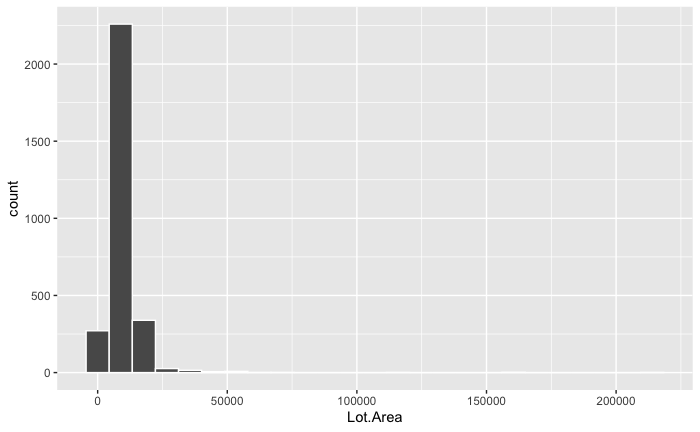

```r
ggplot(clean_names) +
  aes(x = Lot.Area) +
  geom_histogram(bins = 25, col = "white")
```

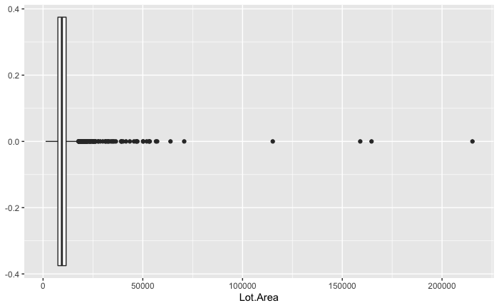

```r
ggplot(clean_names) +
  aes(x = Lot.Area) +
  geom_boxplot()
```

```r
clean_names_stats <- clean_names %>%
  summarise(
    count = n(),
    mean = mean(Lot.Area),
    sd = sd(Lot.Area)
  )
clean_names_stats
```

| count | mean | sd |
| --- | --- | --- |
| 2930 | 10147.92 | 7880.018 |

Q3. Compute and visualise a bootstrap sampling distribution for the mean(lot_area) of the sold houses

```r
bootstrap_clean_names <- clean_names %>%
  rep_sample_n(size = 200, replace = TRUE, reps = 5000) %>%
  summarise(Lot.Area = mean(Lot.Area))
bootstrap_clean_names
```

| replicate | Lot.Area |
| --- | --- |
| 1 | 10370.200 |
| 2 | 9626.410 |
| 3 | 9860.460 |
| 4 | 9977.315 |
| 5 | 9873.325 |
| 6 | 10341.255 |
| 7 | 10040.765 |
| 8 | 9786.710 |
| 9 | 10454.550 |
| 10 | 9789.805 |

[output cut: 990 more lines]

```r
NA
```

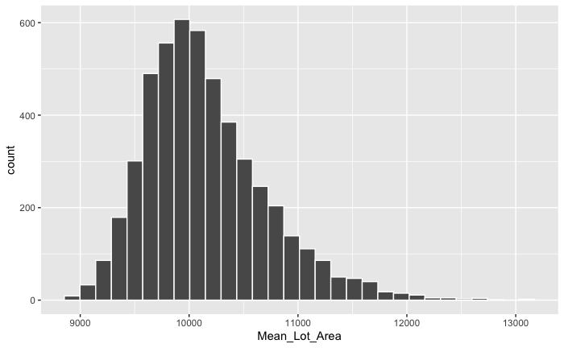

```r
bootstrap_clean_names %>%
  ggplot(aes(x = Lot.Area)) +
  geom_histogram(col = "white") +
  labs(x = "Mean_Lot_Area")
```

Q4. Use your bootstrap distribution to calculate a 95% CI for mean(lot_area), and visualise it on the distribution

```r
ci_95 <- bootstrap_clean_names %>%
  summarise(
    mean = mean(Lot.Area),
    lower_bound = quantile(Lot.Area, probs = 0.025),
    upper_bound = quantile(Lot.Area, probs = 0.975)
  )
ci_95
```

| mean | lower_bound | upper_bound |
| --- | --- | --- |
| 10153.23 | 9283.263 | 11520.87 |

```r
NA
```

```r
infer_clean_names <- clean_names %>%
  specify(response = Lot.Area) %>%
  generate(reps = 5000, type = "bootstrap") %>%
  calculate(stat = "mean")

infer_clean_names
```

| replicate | stat |
| --- | --- |
| 1 | 9937.117 |
| 2 | 10168.896 |
| 3 | 9821.213 |
| 4 | 9987.114 |
| 5 | 10095.882 |
| 6 | 10141.611 |
| 7 | 10319.168 |
| 8 | 10128.232 |
| 9 | 10174.881 |
| 10 | 10074.343 |

[output cut: 990 more lines]

```r
infer_ci_95 <- infer_clean_names %>%
  get_ci(level = 0.95, type = "percentile")
infer_ci_95
```

| lower_ci | upper_ci |
| --- | --- |
| 9878.17 | 10445.55 |

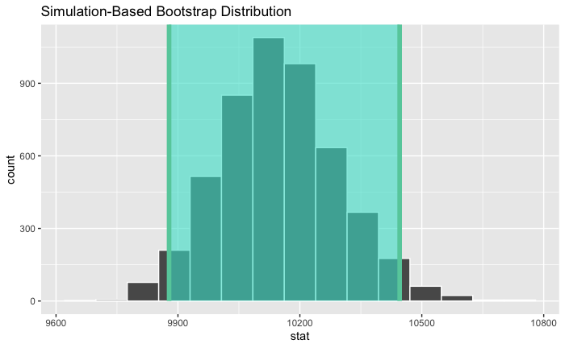

```r
infer_clean_names %>%
  visualise() +
  shade_confidence_interval(endpoints = infer_ci_95)
```

Q5. You would like to know the mean(lot_area) of the sold houses with higher confidence. Calculate the 99% CI for this variable (you can re-use your bootstrap distribution from above). Is it narrower or broader than the 95% CI? Does that make sense? A. The graph is broader of the 99% is broader than the 95%. yes it makes sense as it is now 99% percentile of the total.

```r
infer_ci_99 <- infer_clean_names %>%
  get_ci(level = 0.99, type = "percentile")
infer_ci_99
```

| lower_ci | upper_ci |
| --- | --- |
| 9806.625 | 10564.66 |

```r
NA
```

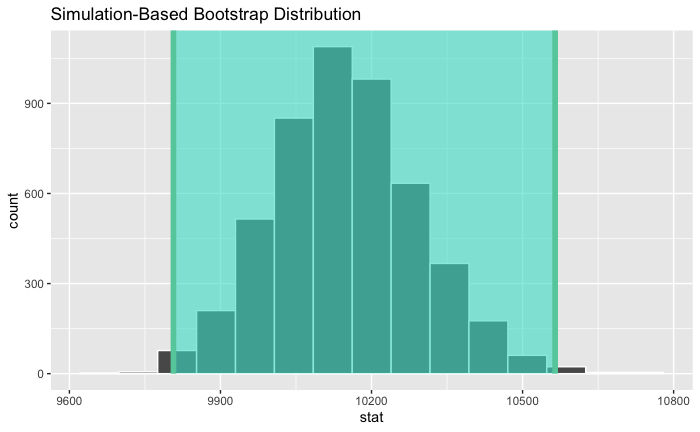

```r
infer_clean_names %>%
  visualise() +
  shade_confidence_interval(endpoints = infer_ci_99)
```

Q6. Calculate the point estimate of the mean(lot_area)

```r
point_ests <- clean_names %>%
  rep_sample_n(size = 50, reps = 1) %>%
  ungroup() %>%
  summarise(
    mean_Lot.Area = mean(Lot.Area),
  )
point_ests
```

| mean_Lot.Area |
| --- |
| 12717.9 |

```r
NA
NA
```